```r
library(tidyverse)  # data manipulation and visualization
library(modelr)     # provides easy pipeline modeling functions
library(broom)      # helps to tidy up model outputs
library(VIM)      # missing value analysis
library(mice)     # missing value analysis
library(Hmisc)    # replace missing values with mean
library(corrplot)
```

## Data loading

```r
##Kidney <- read.csv("C:/Users/Lucas/Desktop/School/Spring2021/DSC341/Final Project/Chronic_Kidney_Disease/kidney.csv")
Kidney <- read.csv("C:/Users/SaraE/dsc341Project/kidney.csv")
```

## Data Cleaning

I’m going to start the cleaning process by re-coding missing values from “?” to “NA”

```r
Kidney[Kidney=="?"]=NA
```

#Convert Columns to ints that need to be

```r
Kidney$age <- as.numeric(Kidney$age)
Kidney$bp <- as.numeric(Kidney$bp)
Kidney$sg <- as.numeric(Kidney$sg)
Kidney$al <- as.numeric(Kidney$al)
Kidney$su <- as.numeric(Kidney$su)
Kidney$bgr <- as.numeric(Kidney$bgr)
Kidney$bu <- as.numeric(Kidney$bu)
Kidney$sc <- as.numeric(Kidney$sc)
Kidney$sod <- as.numeric(Kidney$sod)
Kidney$pot <- as.numeric(Kidney$pot)
Kidney$hemo <- as.numeric(Kidney$hemo)
Kidney$pcv <- as.numeric(Kidney$pcv)
Kidney$wbcc <- as.numeric(Kidney$wbcc)
Kidney$rbcc <- as.numeric(Kidney$rbcc)
```

# Missing Values Analysis

```r
# Find total amount of missing cells
mean(is.na(Kidney)) * 100
```

```
## [1] 9.730769
```

```r
# Display percentage of missing values per column (variable)
colMeans(is.na(Kidney)) * 100
```

```
##    id   age    bp    sg    al    su   rbc    pc   pcc    ba   bgr    bu    sc
##  0.00  2.25  3.00 11.75 11.50 12.25 38.00 16.25  1.00  1.00 11.00  4.75  4.25
##   sod   pot  hemo   pcv  wbcc  rbcc   htn    dm   cad appet    pe   ane class
## 21.75 22.00 13.00 17.75 26.50 32.75  0.50  0.50  0.50  0.25  0.25  0.25  0.00
```

```r
# Display the number of missing values per column (variable)
colSums(is.na(Kidney))
```

```
##    id   age    bp    sg    al    su   rbc    pc   pcc    ba   bgr    bu    sc
##     0     9    12    47    46    49   152    65     4     4    44    19    17
##   sod   pot  hemo   pcv  wbcc  rbcc   htn    dm   cad appet    pe   ane class
##    87    88    52    71   106   131     2     2     2     1     1     1     0
```

```r
## Remove rows where a nomninal value is NA
Kidney = Kidney[complete.cases(Kidney[7:10]),]
Kidney = Kidney[complete.cases(Kidney[20:25]),]
```

# Redefine labels for categorical variables

This adds columns to the end of the table. Each new column is named after an existing categorical variable with an “f” for “float” added to the end. (i.e. rbc -> rbcf) These new columns hold numerical representaions of the categorical variable which allows us to do things like mean.

```r
Kidney$rbcf=factor(Kidney$rbc, levels=c("normal","abnormal"), labels=c(1, 2))
Kidney$pcf=factor(Kidney$pc, levels=c("normal","abnormal"), labels=c(1, 2))
Kidney$pccf=factor(Kidney$pcc, levels=c("present", "notpresent"), labels=c(1,2))
Kidney$baf=factor(Kidney$ba, levels=c("present", "notpresent"), labels=c(1,2))
Kidney$htnf=factor(Kidney$htn, levels=c("yes", "no"), labels=c(1,2))
Kidney$dmf=factor(Kidney$dm, levels=c("yes", "no"), labels=c(1,2))
Kidney$cadf=factor(Kidney$cad, levels=c("yes", "no"), labels=c(1,2))
Kidney$appetf=factor(Kidney$appet, levels=c("good", "poor"), labels=c(1,2))
Kidney$pef=factor(Kidney$pe, levels=c("yes", "no"), labels=c(1,2))
Kidney$anef=factor(Kidney$ane, levels=c("yes", "no"), labels=c(1,2))
Kidney$classf=factor(Kidney$class, levels=c("ckd", "notckd"), labels=c(1,2))
```

# Deal with missing values

The plan here is to have 2 tables total. One will not touch the data at all; leaving the missing values alone. Another will replace the missing values with the mean or median value of each variable

Kidney: has missing values, string representations for some variables (i.e. “normal”/“abnormal”) kidneyMenas: has no missing values, uses mean for missing values that are represented as ints and mean for values that are reprsented as strings

```r
kidneyMeans=Kidney
kidneyMeans$imputed_age <- with(kidneyMeans, impute(age, mean))
kidneyMeans$imputed_bp <- with(kidneyMeans, impute(bp, mean))
kidneyMeans$imputed_sg <- with(kidneyMeans, impute(sg, mean))
kidneyMeans$imputed_al <- with(kidneyMeans, impute(al, mean))
kidneyMeans$imputed_su <- with(kidneyMeans, impute(su, mean))
kidneyMeans$imputed_bgr <- with(kidneyMeans, impute(bgr, mean))
kidneyMeans$imputed_bu <- with(kidneyMeans, impute(bu, mean))
kidneyMeans$imputed_sc <- with(kidneyMeans, impute(sc, mean))
kidneyMeans$imputed_sod <- with(kidneyMeans, impute(sod, mean))
kidneyMeans$imputed_pot <- with(kidneyMeans, impute(pot, mean))
kidneyMeans$imputed_hemo <- with(kidneyMeans, impute(hemo, mean))
kidneyMeans$imputed_pcv <- with(kidneyMeans, impute(pcv, mean))
kidneyMeans$imputed_wbcc <- with(kidneyMeans, impute(wbcc, mean))
kidneyMeans$imputed_rbcc <- with(kidneyMeans, impute(rbcc, mean))

kidneyMeans = kidneyMeans[c(1, 38:42, 7:10,  43:51, 20:26)]
```

# Anaylisis of outylier and unusal values

```r
# Shows stats for outliers

#$stats = statistic used to build boxplot {min*, q1, median
  #q3, max*} (min* and max* excluding extreme values)

#$n = sample size

#$out = the values of any data points which lie beyond the
# extremes of the whiskers

# The which(is.na ...) statement will show the ID number for the corresponding value

b=boxplot.stats(Kidney$su)
b
```

```
## $stats
## [1] 0 0 0 0 0
##
## $n
## [1] 232
##
## $conf
## [1] 0 0
##
## $out
##  [1] 3 4 2 4 1 4 3 2 1 2 3 4 3 1 1 3 2 1 4 1 1 2 2 2 4 1 5 2 3 3 1
```

```r
which(is.na(match(Kidney$su, b$out))==FALSE)
```

```
##  [1]  1  4  8 12 15 23 25 36 37 39 46 51 54 55 58 59 62 68 70 74 78 80 81 82 83
## [26] 84 86 87 94 97 98
```

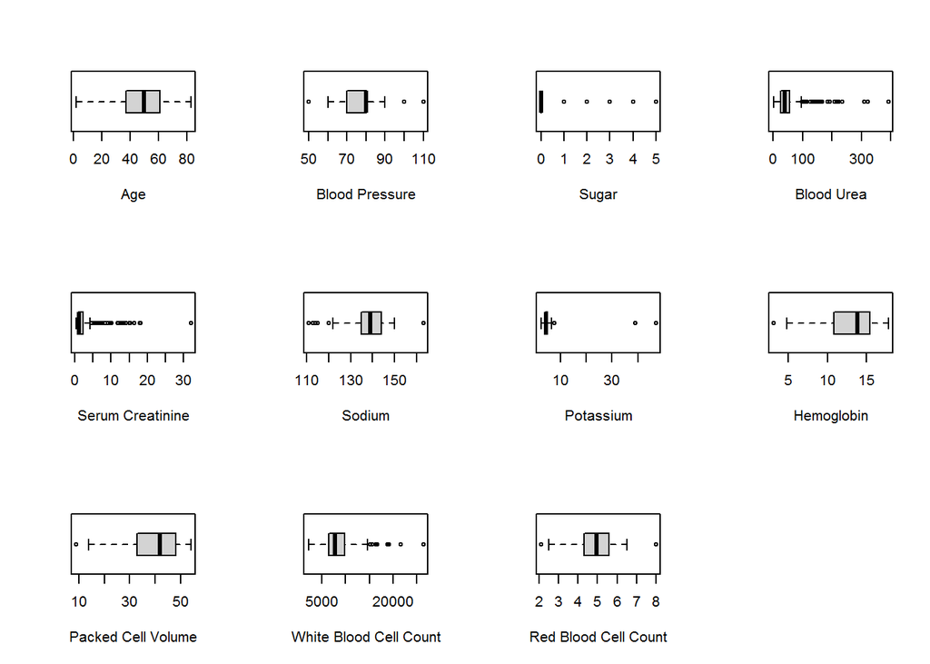

```r
par(mfrow=c(3,4))
boxplot(Kidney$age, xlab = "Age", horizontal = TRUE)
boxplot(Kidney$bp, xlab = "Blood Pressure", horizontal = TRUE)
boxplot(Kidney$su, xlab = "Sugar", horizontal = TRUE)
boxplot(Kidney$bu, xlab = "Blood Urea", horizontal = TRUE)
boxplot(Kidney$sc, xlab = "Serum Creatinine", horizontal = TRUE)
boxplot(Kidney$sod, xlab = "Sodium", horizontal = TRUE)
boxplot(Kidney$pot, xlab = "Potassium", horizontal = TRUE)
boxplot(Kidney$hemo, xlab = "Hemoglobin", horizontal = TRUE)
boxplot(Kidney$pcv, xlab = "Packed Cell Volume", horizontal = TRUE)
boxplot(Kidney$wbcc, xlab = "White Blood Cell Count", horizontal = TRUE)
boxplot(Kidney$rbcc, xlab = "Red Blood Cell Count", horizontal = TRUE)
```

# Associations Between Variables

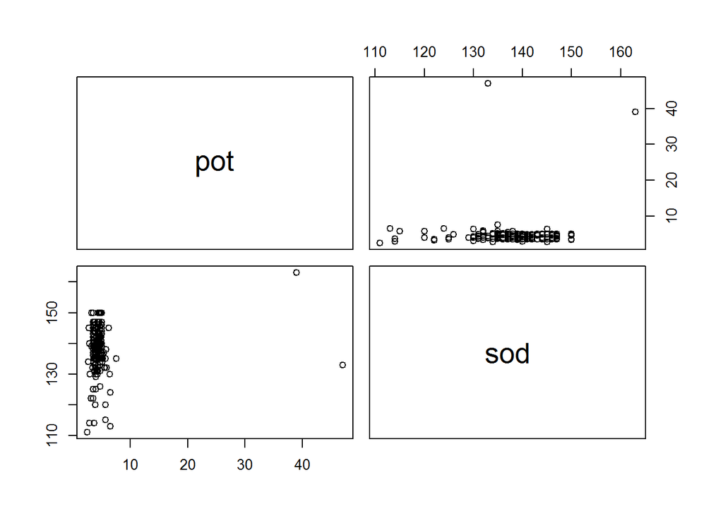

```r
##pairs(~age+bp+sg+su+bgr+bu+sc+sod+pot+hemo+pcv+wbcc+rbcc, data=Kidney)
pairs(~pot+sod, data=Kidney)
```

# Correlation Plot

!!! THIS ASSUMES KIDNEYMEANS IS LOADED ALREADY !!!

```r
library("corrplot")
source("http://www.sthda.com/upload/rquery_cormat.r")

kidneySubset <- kidneyMeans[, c(2:6, 11:19)]

head(kidneySubset)
```

```
##    imputed_age imputed_bp imputed_sg imputed_al imputed_su imputed_bgr
## 3           62   80.00000      1.010          2          3         423
## 4           48   70.00000      1.005          4          0         117
## 5           51   80.00000      1.010          2          0         106
## 8           24   75.02183      1.015          2          4         410
## 9           52  100.00000      1.015          3          0         138
## 10          53   90.00000      1.020          2          0          70
##    imputed_bu imputed_sc imputed_sod imputed_pot imputed_hemo imputed_pcv
## 3          53        1.8    138.5297     4.74802          9.6          31
## 4          56        3.8    111.0000     2.50000         11.2          32
## 5          26        1.4    138.5297     4.74802         11.6          35
## 8          31        1.1    138.5297     4.74802         12.4          44
## 9          60        1.9    138.5297     4.74802         10.8          33
## 10        107        7.2    114.0000     3.70000          9.5          29
##    imputed_wbcc imputed_rbcc
## 3          7500     4.869355
## 4          6700     3.900000
## 5          7300     4.600000
## 8          6900     5.000000
## 9          9600     4.000000
## 10        12100     3.700000
```

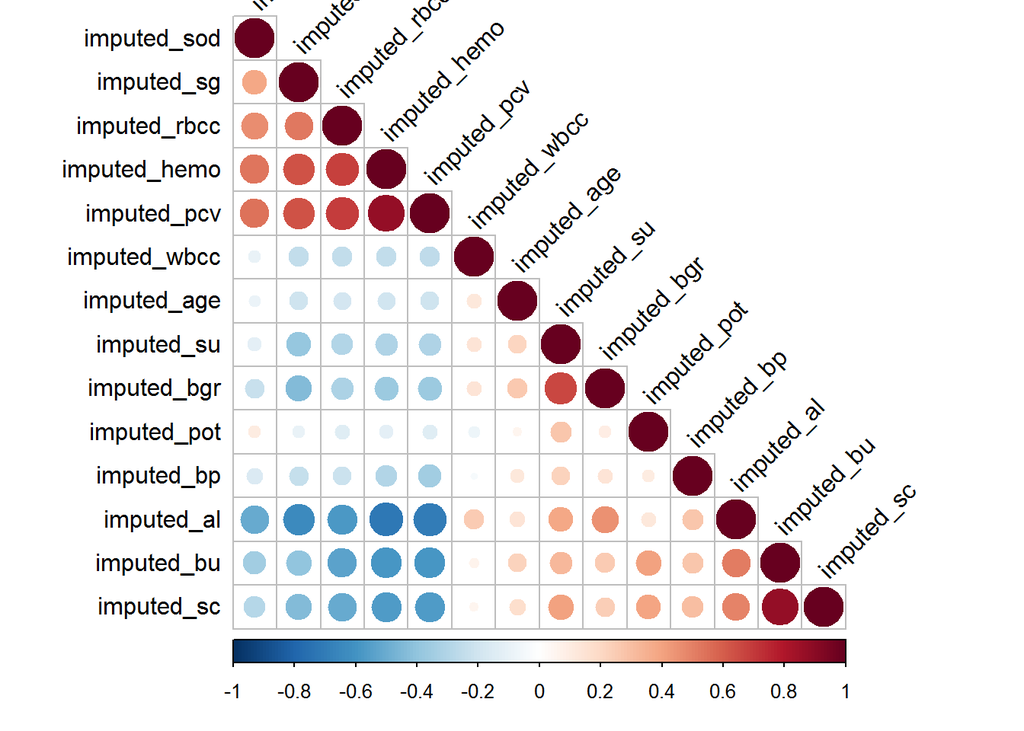

```
## $r
##              imputed_sod imputed_sg imputed_rbcc imputed_hemo imputed_pcv
## imputed_sod            1
## imputed_sg          0.38          1
## imputed_rbcc        0.46       0.52            1
## imputed_hemo        0.53       0.63         0.68            1
## imputed_pcv         0.54       0.63         0.69         0.87           1
## imputed_wbcc      -0.091      -0.25        -0.25        -0.25       -0.26
## imputed_age       -0.082      -0.21        -0.19         -0.2       -0.21
## imputed_su         -0.12      -0.39         -0.3        -0.31       -0.31
## imputed_bgr        -0.23      -0.44        -0.32        -0.37       -0.37
## imputed_pot          0.1       -0.1        -0.14        -0.12       -0.14
## imputed_bp         -0.16      -0.24        -0.22         -0.3       -0.34
## imputed_al         -0.51      -0.64        -0.58        -0.72        -0.7
## imputed_bu         -0.34       -0.4        -0.54        -0.59       -0.59
## imputed_sc         -0.29      -0.44        -0.51        -0.57       -0.57
##              imputed_wbcc imputed_age imputed_su imputed_bgr imputed_pot
## imputed_sod
## imputed_sg
## imputed_rbcc
## imputed_hemo
## imputed_pcv
## imputed_wbcc            1
## imputed_age          0.13           1
## imputed_su           0.14        0.21          1
## imputed_bgr          0.14        0.26       0.66           1
## imputed_pot         -0.08       0.058       0.27       0.093           1
## imputed_bp         -0.033        0.12       0.22        0.14         0.1
## imputed_al           0.25        0.15       0.38        0.45        0.13
## imputed_bu          0.068        0.22       0.32        0.25         0.4
## imputed_sc           0.05        0.17        0.4        0.24        0.39
##              imputed_bp imputed_al imputed_bu imputed_sc
## imputed_sod
## imputed_sg
## imputed_rbcc
## imputed_hemo
## imputed_pcv
## imputed_wbcc
## imputed_age
## imputed_su
```

[output cut: 87 more lines]

```
## imputed_sg
## imputed_rbcc
## imputed_hemo
## imputed_pcv
## imputed_wbcc
## imputed_age
## imputed_su
## imputed_bgr
## imputed_pot
## imputed_bp   1
## imputed_al              1
## imputed_bu              .          1
## imputed_sc              .          +          1
## attr(,"legend")
## [1] 0 ' ' 0.3 '.' 0.6 ',' 0.8 '+' 0.9 '*' 0.95 'B' 1
```

```r
rquery.cormat(kidneySubset)
```

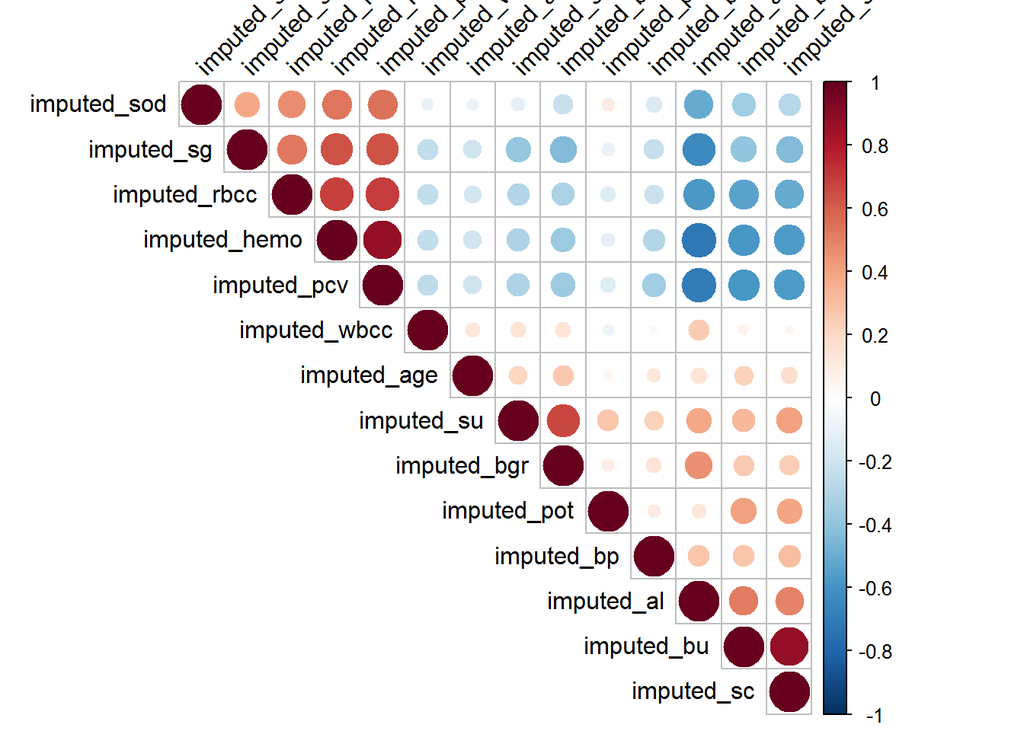

```
## $r
##              imputed_sod imputed_sg imputed_rbcc imputed_hemo imputed_pcv
## imputed_sod            1       0.38         0.46         0.53        0.54
## imputed_sg                        1         0.52         0.63        0.63
## imputed_rbcc                                   1         0.68        0.69
## imputed_hemo                                                1        0.87
## imputed_pcv                                                             1
## imputed_wbcc
## imputed_age
## imputed_su
## imputed_bgr
## imputed_pot
## imputed_bp
## imputed_al
## imputed_bu
## imputed_sc
##              imputed_wbcc imputed_age imputed_su imputed_bgr imputed_pot
## imputed_sod        -0.091      -0.082      -0.12       -0.23         0.1
## imputed_sg          -0.25       -0.21      -0.39       -0.44        -0.1
## imputed_rbcc        -0.25       -0.19       -0.3       -0.32       -0.14
## imputed_hemo        -0.25        -0.2      -0.31       -0.37       -0.12
## imputed_pcv         -0.26       -0.21      -0.31       -0.37       -0.14
## imputed_wbcc            1        0.13       0.14        0.14       -0.08
## imputed_age                         1       0.21        0.26       0.058
## imputed_su                                     1        0.66        0.27
## imputed_bgr                                                1       0.093
## imputed_pot                                                            1
## imputed_bp
## imputed_al
## imputed_bu
## imputed_sc
##              imputed_bp imputed_al imputed_bu imputed_sc
## imputed_sod       -0.16      -0.51      -0.34      -0.29
## imputed_sg        -0.24      -0.64       -0.4      -0.44
## imputed_rbcc      -0.22      -0.58      -0.54      -0.51
## imputed_hemo       -0.3      -0.72      -0.59      -0.57
## imputed_pcv       -0.34       -0.7      -0.59      -0.57
## imputed_wbcc     -0.033       0.25      0.068       0.05
## imputed_age        0.12       0.15       0.22       0.17
## imputed_su         0.22       0.38       0.32        0.4
```

[output cut: 87 more lines]

```
## imputed_sg              ,          .          .
## imputed_rbcc            .          .          .
## imputed_hemo            ,          .          .
## imputed_pcv  .          ,          .          .
## imputed_wbcc
## imputed_age
## imputed_su              .          .          .
## imputed_bgr             .
## imputed_pot                        .          .
## imputed_bp   1
## imputed_al              1          .          .
## imputed_bu                         1          +
## imputed_sc                                    1
## attr(,"legend")
## [1] 0 ' ' 0.3 '.' 0.6 ',' 0.8 '+' 0.9 '*' 0.95 'B' 1
```

```r
rquery.cormat(kidneySubset, type="upper")
```

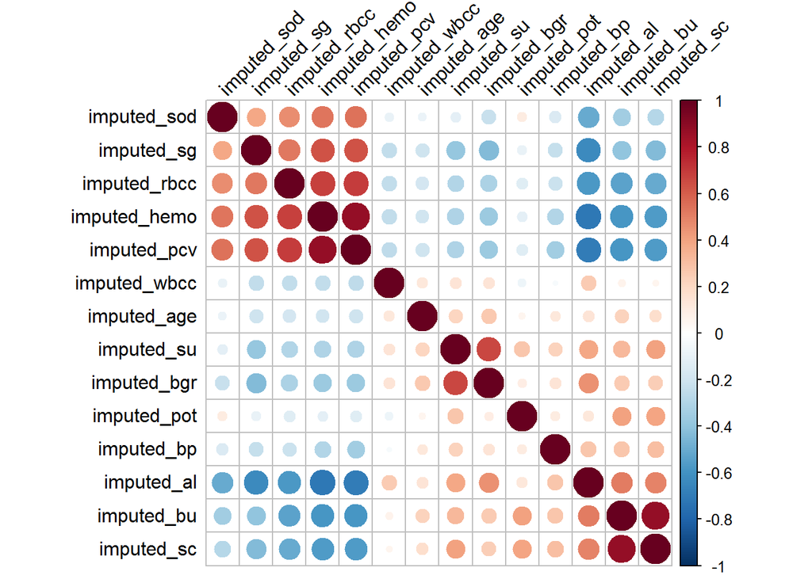

```
## $r
##              imputed_sod imputed_sg imputed_rbcc imputed_hemo imputed_pcv
## imputed_sod        1.000       0.38         0.46         0.53        0.54
## imputed_sg         0.380       1.00         0.52         0.63        0.63
## imputed_rbcc       0.460       0.52         1.00         0.68        0.69
## imputed_hemo       0.530       0.63         0.68         1.00        0.87
## imputed_pcv        0.540       0.63         0.69         0.87        1.00
## imputed_wbcc      -0.091      -0.25        -0.25        -0.25       -0.26
## imputed_age       -0.082      -0.21        -0.19        -0.20       -0.21
## imputed_su        -0.120      -0.39        -0.30        -0.31       -0.31
## imputed_bgr       -0.230      -0.44        -0.32        -0.37       -0.37
## imputed_pot        0.100      -0.10        -0.14        -0.12       -0.14
## imputed_bp        -0.160      -0.24        -0.22        -0.30       -0.34
## imputed_al        -0.510      -0.64        -0.58        -0.72       -0.70
## imputed_bu        -0.340      -0.40        -0.54        -0.59       -0.59
## imputed_sc        -0.290      -0.44        -0.51        -0.57       -0.57
##              imputed_wbcc imputed_age imputed_su imputed_bgr imputed_pot
## imputed_sod        -0.091      -0.082      -0.12      -0.230       0.100
## imputed_sg         -0.250      -0.210      -0.39      -0.440      -0.100
## imputed_rbcc       -0.250      -0.190      -0.30      -0.320      -0.140
## imputed_hemo       -0.250      -0.200      -0.31      -0.370      -0.120
## imputed_pcv        -0.260      -0.210      -0.31      -0.370      -0.140
## imputed_wbcc        1.000       0.130       0.14       0.140      -0.080
## imputed_age         0.130       1.000       0.21       0.260       0.058
## imputed_su          0.140       0.210       1.00       0.660       0.270
## imputed_bgr         0.140       0.260       0.66       1.000       0.093
## imputed_pot        -0.080       0.058       0.27       0.093       1.000
## imputed_bp         -0.033       0.120       0.22       0.140       0.100
## imputed_al          0.250       0.150       0.38       0.450       0.130
## imputed_bu          0.068       0.220       0.32       0.250       0.400
## imputed_sc          0.050       0.170       0.40       0.240       0.390
##              imputed_bp imputed_al imputed_bu imputed_sc
## imputed_sod      -0.160      -0.51     -0.340      -0.29
## imputed_sg       -0.240      -0.64     -0.400      -0.44
## imputed_rbcc     -0.220      -0.58     -0.540      -0.51
## imputed_hemo     -0.300      -0.72     -0.590      -0.57
## imputed_pcv      -0.340      -0.70     -0.590      -0.57
## imputed_wbcc     -0.033       0.25      0.068       0.05
## imputed_age       0.120       0.15      0.220       0.17
## imputed_su        0.220       0.38      0.320       0.40
```

[output cut: 87 more lines]

```
## imputed_sg
## imputed_rbcc
## imputed_hemo
## imputed_pcv
## imputed_wbcc
## imputed_age
## imputed_su
## imputed_bgr
## imputed_pot
## imputed_bp   1
## imputed_al              1
## imputed_bu              .          1
## imputed_sc              .          +          1
## attr(,"legend")
## [1] 0 ' ' 0.3 '.' 0.6 ',' 0.8 '+' 0.9 '*' 0.95 'B' 1
```

```r
rquery.cormat(kidneySubset, type="full")
```

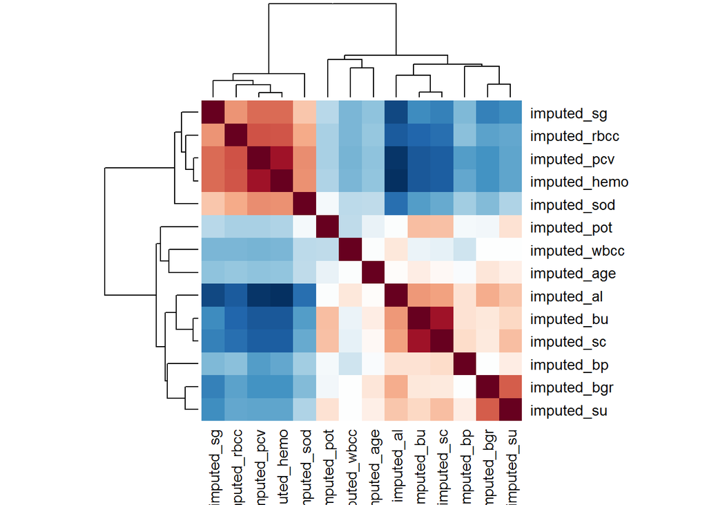

```r
cormat<-rquery.cormat(kidneySubset, graphType="heatmap")
```

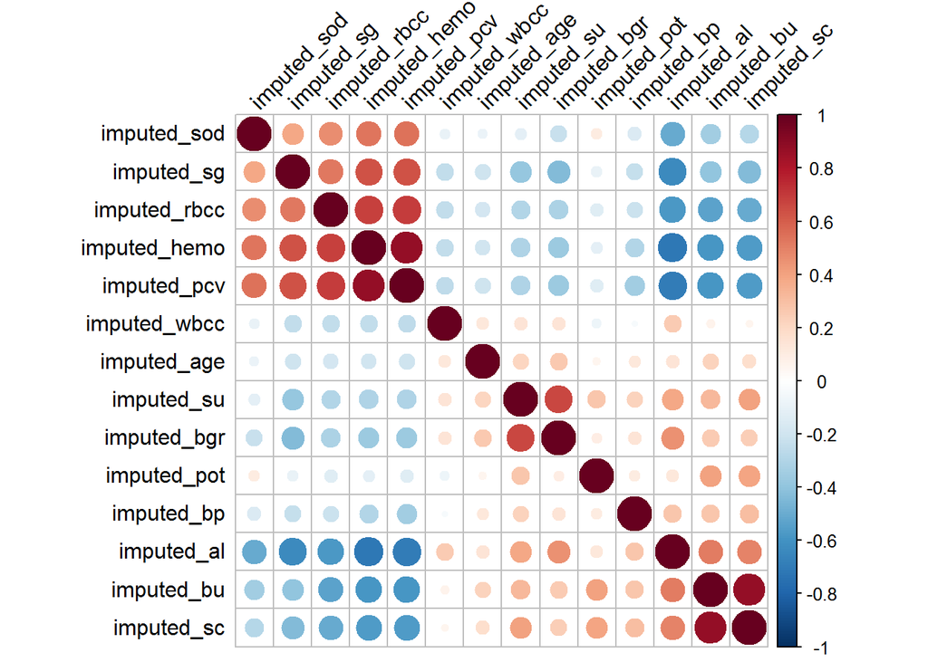

```
## $r
##              imputed_sod imputed_sg imputed_rbcc imputed_hemo imputed_pcv
## imputed_sod        1.000       0.38         0.46         0.53        0.54
## imputed_sg         0.380       1.00         0.52         0.63        0.63
## imputed_rbcc       0.460       0.52         1.00         0.68        0.69
## imputed_hemo       0.530       0.63         0.68         1.00        0.87
## imputed_pcv        0.540       0.63         0.69         0.87        1.00
## imputed_wbcc      -0.091      -0.25        -0.25        -0.25       -0.26
## imputed_age       -0.082      -0.21        -0.19        -0.20       -0.21
## imputed_su        -0.120      -0.39        -0.30        -0.31       -0.31
## imputed_bgr       -0.230      -0.44        -0.32        -0.37       -0.37
## imputed_pot        0.100      -0.10        -0.14        -0.12       -0.14
## imputed_bp        -0.160      -0.24        -0.22        -0.30       -0.34
## imputed_al        -0.510      -0.64        -0.58        -0.72       -0.70
## imputed_bu        -0.340      -0.40        -0.54        -0.59       -0.59
## imputed_sc        -0.290      -0.44        -0.51        -0.57       -0.57
##              imputed_wbcc imputed_age imputed_su imputed_bgr imputed_pot
## imputed_sod        -0.091      -0.082      -0.12      -0.230       0.100
## imputed_sg         -0.250      -0.210      -0.39      -0.440      -0.100
## imputed_rbcc       -0.250      -0.190      -0.30      -0.320      -0.140
## imputed_hemo       -0.250      -0.200      -0.31      -0.370      -0.120
## imputed_pcv        -0.260      -0.210      -0.31      -0.370      -0.140
## imputed_wbcc        1.000       0.130       0.14       0.140      -0.080
## imputed_age         0.130       1.000       0.21       0.260       0.058
## imputed_su          0.140       0.210       1.00       0.660       0.270
## imputed_bgr         0.140       0.260       0.66       1.000       0.093
## imputed_pot        -0.080       0.058       0.27       0.093       1.000
## imputed_bp         -0.033       0.120       0.22       0.140       0.100
## imputed_al          0.250       0.150       0.38       0.450       0.130
## imputed_bu          0.068       0.220       0.32       0.250       0.400
## imputed_sc          0.050       0.170       0.40       0.240       0.390
##              imputed_bp imputed_al imputed_bu imputed_sc
## imputed_sod      -0.160      -0.51     -0.340      -0.29
## imputed_sg       -0.240      -0.64     -0.400      -0.44
## imputed_rbcc     -0.220      -0.58     -0.540      -0.51
## imputed_hemo     -0.300      -0.72     -0.590      -0.57
## imputed_pcv      -0.340      -0.70     -0.590      -0.57
## imputed_wbcc     -0.033       0.25      0.068       0.05
## imputed_age       0.120       0.15      0.220       0.17
## imputed_su        0.220       0.38      0.320       0.40
```

[output cut: 87 more lines]

```
## imputed_sg
## imputed_rbcc
## imputed_hemo
## imputed_pcv
## imputed_wbcc
## imputed_age
## imputed_su
## imputed_bgr
## imputed_pot
## imputed_bp   1
## imputed_al              1
## imputed_bu              .          1
## imputed_sc              .          +          1
## attr(,"legend")
## [1] 0 ' ' 0.3 '.' 0.6 ',' 0.8 '+' 0.9 '*' 0.95 'B' 1
```

```r
rquery.cormat(kidneySubset, type="full")
```

```r
table(kidneyMeans$class) # compute table of counts
```

```
##
##    ckd notckd
##     98    135
```

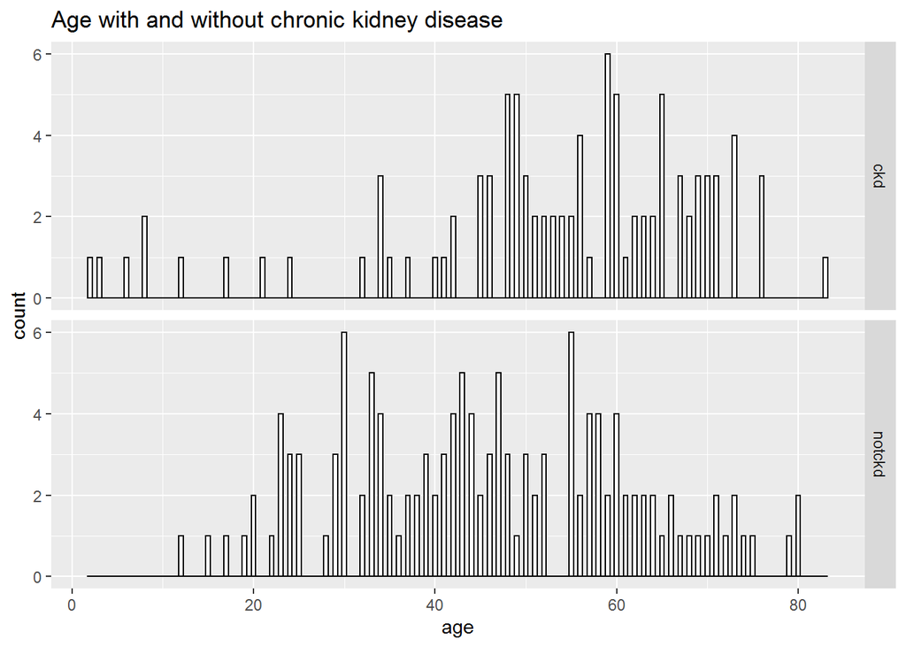

```r
t=table(kidneyMeans$class)

ggplot(kidneyMeans, aes(x=imputed_age)) + geom_histogram(binwidth=.5, colour="black", fill="white") + facet_grid(class ~ .) + labs(title = "Age with and without chronic kidney disease", x ="age")
```

```r
##summary(kidneyMeans$class)
```

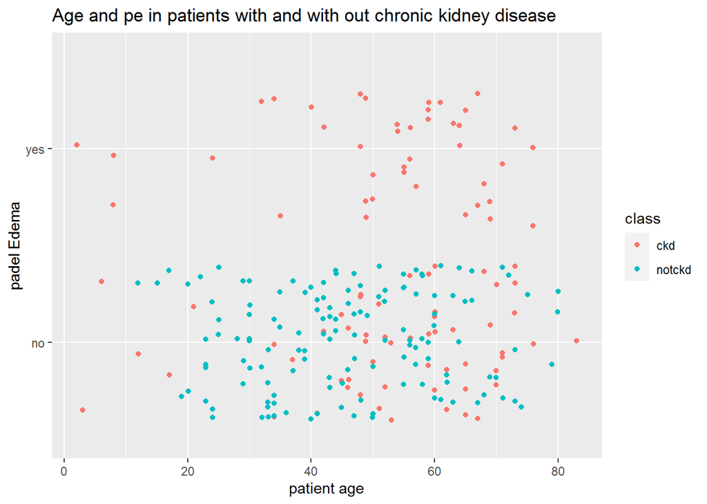

```r
##plot(x = kidneys$sod, y = kidneys$pot)set.seed(341)
##data(kidneys)
kidneyMeans <- as_tibble(kidneyMeans)

x0 <- kidneyMeans %>% dplyr::select(imputed_age, pe, class)


##x0$imputed_pe=factor(x0$imputed_pe, levels=c(1,2), labels=c("Yes","No"))

k0 <- ggplot(x0, aes(x = imputed_age, y = pe, color = class)) + geom_jitter()


k0 + labs(title = "Age and pe in patients with and with out chronic kidney disease", x ="patient age", y="padel Edema")
```